# R Notebook

```r
rm(list=ls(all=TRUE))
assay <- read.csv("Assay.csv", header = TRUE)

assay
```

| X | Block | sample | dilut | logDens |
| --- | --- | --- | --- | --- |
| 1 | 1 | a | 1 | -0.23319389 |
| 2 | 1 | a | 2 | -0.05657035 |
| 3 | 1 | a | 3 | 0.21107097 |
| 4 | 1 | a | 4 | 0.34642257 |
| 5 | 1 | a | 5 | 0.59387918 |
| 6 | 1 | b | 1 | -0.09871597 |
| 7 | 1 | b | 2 | 0.13190507 |
| 8 | 1 | b | 3 | 0.28292076 |
| 9 | 1 | b | 4 | 0.59387918 |
| 10 | 1 | b | 5 | 0.58834207 |

[output cut: 50 more lines]

[output not shown]

We first load the data into R then look at the proposed research question. Does the dilution level determine the number of living cells in a sample, as determined by optical density?

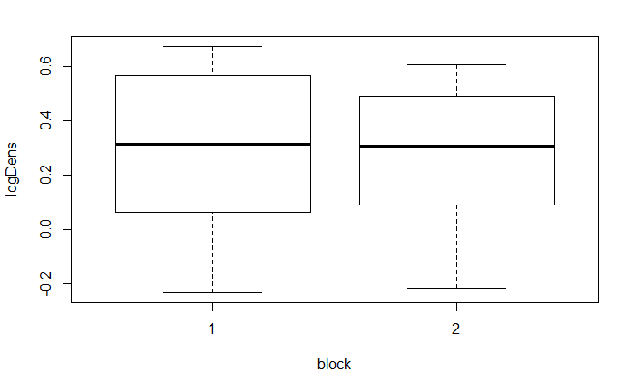

```r
block <- as.factor(assay$Block)
plot(logDens ~ block, data = assay)
```

Next, we try plotting each factor against the response variable, logDens so that we can better formulate a hypothesis. First, we plot the block difference. The means seem to be similar, if not equal, to each other. However, this is not enough to reach any conclusion.

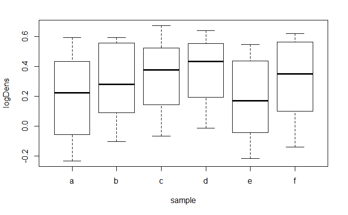

```r
plot(logDens ~ sample, data = assay)
```

Next, we try and see if there is any variance among the samples themselves. This time, we see a larger variance in and among the samples.

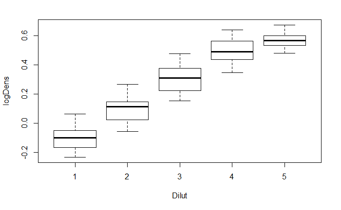

```r
Dilut <- as.factor(assay$dilut)
plot(logDens ~ Dilut, data = assay)
```

Finally, we take a look at the last and perhaps the most directly influential variable. We see that as it becomes less diluted, the logarithm of the optical density increases. However, as it becomes less diluted, the change in increase of the optical density decreases.

Now, we formualte our hypotheses. Our null hypothesis is that dilution does not affect the logarithmic optical density. Our alternative hypothesis is that dilution does affect the logartihmic optical density. We arrive at this conclusion since we would like to show that the change is the status quo.

```r
library(lme4)
assay.lmer <- lmer(logDens ~ (1 | Block) + (1| sample) + dilut, data = assay, REML = FALSE)
summary(assay.lmer)
```

```
Linear mixed model fit by maximum likelihood  ['lmerMod']
Formula: logDens ~ (1 | Block) + (1 | sample) + dilut
   Data: assay

     AIC      BIC   logLik deviance df.resid
  -136.9   -126.4     73.4   -146.9       55

Scaled residuals:
     Min       1Q   Median       3Q      Max
-2.38412 -0.53368  0.02595  0.63137  2.16871

Random effects:
 Groups   Name        Variance  Std.Dev.
 sample   (Intercept) 0.0042639 0.06530
 Block    (Intercept) 0.0001116 0.01057
 Residual             0.0039075 0.06251
Number of obs: 60, groups:  sample, 6; Block, 2

Fixed effects:
             Estimate Std. Error t value
(Intercept) -0.251351   0.033536  -7.495
dilut        0.174783   0.005706  30.630

Correlation of Fixed Effects:
      (Intr)
dilut -0.510
```

```r
assay.lmer.1 <- lmer(logDens ~  (1| sample) + dilut, data = assay, REML = FALSE)
summary(assay.lmer.1)
```

```
Linear mixed model fit by maximum likelihood  ['lmerMod']
Formula: logDens ~ (1 | sample) + dilut
   Data: assay

     AIC      BIC   logLik deviance df.resid
  -138.6   -130.2     73.3   -146.6       56

Scaled residuals:
     Min       1Q   Median       3Q      Max
-2.44345 -0.52156  0.05118  0.62753  2.23424

Random effects:
 Groups   Name        Variance Std.Dev.
 sample   (Intercept) 0.004204 0.06484
 Residual             0.003983 0.06311
Number of obs: 60, groups:  sample, 6

Fixed effects:
             Estimate Std. Error t value
(Intercept) -0.251351   0.032647  -7.699
dilut        0.174783   0.005761  30.336

Correlation of Fixed Effects:
      (Intr)
dilut -0.529
```

```r
anova(assay.lmer.1, assay.lmer)
```

```
Data: assay
Models:
assay.lmer.1: logDens ~ (1 | sample) + dilut
assay.lmer: logDens ~ (1 | Block) + (1 | sample) + dilut
             Df     AIC     BIC logLik deviance  Chisq Chi Df Pr(>Chisq)
assay.lmer.1  4 -138.58 -130.21 73.291  -146.58
assay.lmer    5 -136.87 -126.39 73.433  -146.87 0.2828      1     0.5949
```

```r
assay.lmer.2 <- lmer(logDens ~ (1 | Block)  + dilut, data = assay, REML = FALSE)
```

```
boundary (singular) fit: see ?isSingular
```

```r
summary(assay.lmer.2)
```

```
Linear mixed model fit by maximum likelihood  ['lmerMod']
Formula: logDens ~ (1 | Block) + dilut
   Data: assay

     AIC      BIC   logLik deviance df.resid
  -110.0   -101.7     59.0   -118.0       56

Scaled residuals:
     Min       1Q   Median       3Q      Max
-1.73095 -0.71897 -0.00679  0.61128  2.25978

Random effects:
 Groups   Name        Variance Std.Dev.
 Block    (Intercept) 0.000000 0.00000
 Residual             0.008188 0.09049
Number of obs: 60, groups:  Block, 2

Fixed effects:
            Estimate Std. Error t value
(Intercept) -0.25135    0.02740  -9.175
dilut        0.17478    0.00826  21.160

Correlation of Fixed Effects:
      (Intr)
dilut -0.905
convergence code: 0
boundary (singular) fit: see ?isSingular
```

```r
anova(assay.lmer.2, assay.lmer)
```

```
Data: assay
Models:
assay.lmer.2: logDens ~ (1 | Block) + dilut
assay.lmer: logDens ~ (1 | Block) + (1 | sample) + dilut
             Df     AIC     BIC logLik deviance Chisq Chi Df Pr(>Chisq)
assay.lmer.2  4 -110.04 -101.66 59.018  -118.04
assay.lmer    5 -136.87 -126.39 73.433  -146.87 28.83      1  7.903e-08 ***
---
Signif. codes:  0 ‘***’ 0.001 ‘**’ 0.01 ‘*’ 0.05 ‘.’ 0.1 ‘ ’ 1
```

```r
assay.lmer.3 <- lmer(logDens ~ (1 | Block) + (1| sample), data = assay, REML = FALSE)
```

```
boundary (singular) fit: see ?isSingular
```

```r
summary(assay.lmer.3)
```

```
Linear mixed model fit by maximum likelihood  ['lmerMod']
Formula: logDens ~ (1 | Block) + (1 | sample)
   Data: assay

     AIC      BIC   logLik deviance df.resid
    18.1     26.5     -5.1     10.1       56

Scaled residuals:
    Min      1Q  Median      3Q     Max
-1.9231 -0.7178  0.1475  0.9071  1.5291

Random effects:
 Groups   Name        Variance Std.Dev.
 sample   (Intercept) 0.00000  0.0000
 Block    (Intercept) 0.00000  0.0000
 Residual             0.06929  0.2632
Number of obs: 60, groups:  sample, 6; Block, 2

Fixed effects:
            Estimate Std. Error t value
(Intercept)  0.27300    0.03398   8.034
convergence code: 0
boundary (singular) fit: see ?isSingular
```

```r
anova(assay.lmer.3, assay.lmer)
```

```
Data: assay
Models:
assay.lmer.3: logDens ~ (1 | Block) + (1 | sample)
assay.lmer: logDens ~ (1 | Block) + (1 | sample) + dilut
             Df      AIC      BIC logLik deviance  Chisq Chi Df Pr(>Chisq)
assay.lmer.3  4   18.102   26.479 -5.051   10.102
assay.lmer    5 -136.865 -126.393 73.433 -146.865 156.97      1  < 2.2e-16 ***
---
Signif. codes:  0 ‘***’ 0.001 ‘**’ 0.01 ‘*’ 0.05 ‘.’ 0.1 ‘ ’ 1
```

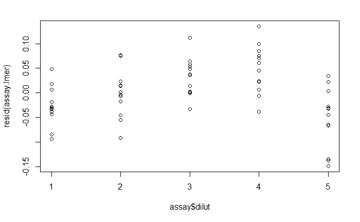

```r
plot(resid(assay.lmer) ~ assay$dilut)
```

Furthemore, this model could have a threshold, as shown as by the residual. To find the threshold, we plot the dilution against the base function of the logarithmic function.

```r
assay$Dens <- 10^assay$logDens
assay
```

| X | Block | sample | dilut | logDens | Dens |
| --- | --- | --- | --- | --- | --- |
| 1 | 1 | a | 1 | -0.23319389 | 0.5845291 |
| 2 | 1 | a | 2 | -0.05657035 | 0.8778689 |
| 3 | 1 | a | 3 | 0.21107097 | 1.6258144 |
| 4 | 1 | a | 4 | 0.34642257 | 2.2203558 |
| 5 | 1 | a | 5 | 0.59387918 | 3.9253572 |
| 6 | 1 | b | 1 | -0.09871597 | 0.7966802 |
| 7 | 1 | b | 2 | 0.13190507 | 1.3548932 |
| 8 | 1 | b | 3 | 0.28292076 | 1.9183187 |
| 9 | 1 | b | 4 | 0.59387918 | 3.9253572 |
| 10 | 1 | b | 5 | 0.58834207 | 3.8756279 |

[output cut: 50 more lines]

[output not shown]

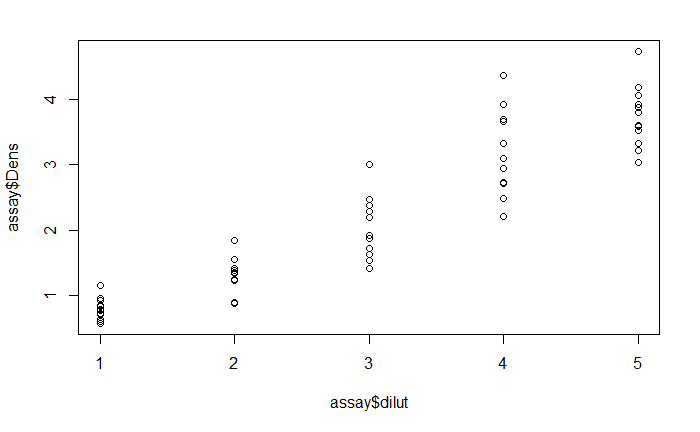

```r
plot(assay$Dens ~ assay$dilut)
```